# Introduction:

**We will dive into features which might cause HeartDisease and gonna try a trusted model to predict individual probability of developing HeartDisease**

**Ratio of HeartDisease is approximately balanced**

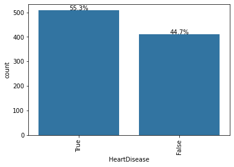

**Propotion of Males to Females is 79% in our data set**

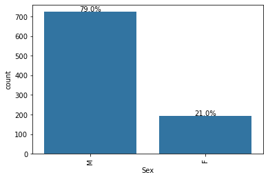

**propotions of ChestPainType**

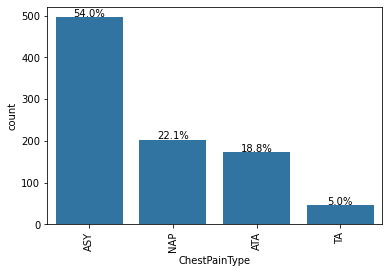

**Propotion of ExerciseAngina**

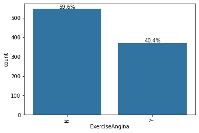

**Propotion of RestingECG**

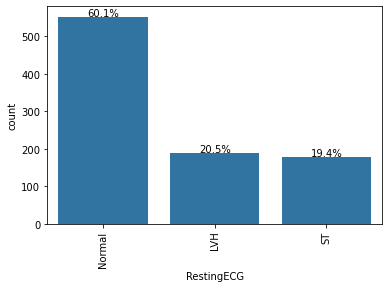

**Feature engineering from mutual information we found ST_Slope has the most effect in heart diseas and [Resting ECG,Fasting BS, Resting BP] most likley to have no effect**

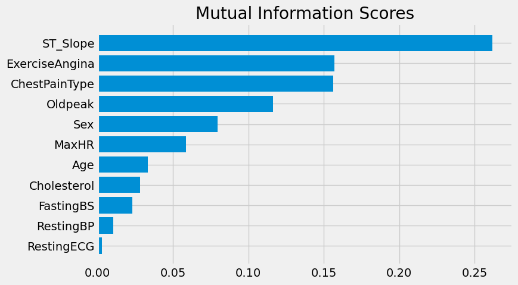

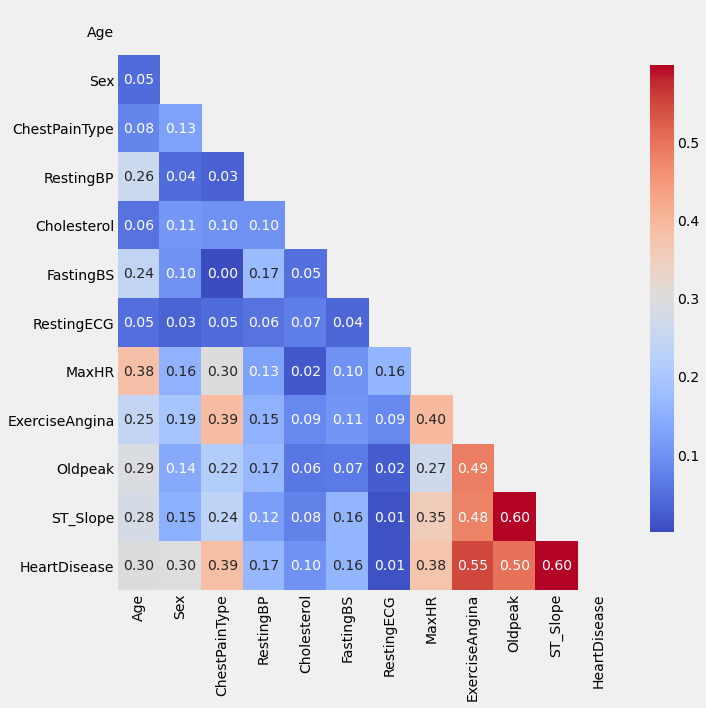

**Building a model using gradient boost classification which is immuned to correlation between features we got an accuracy 81.53153153153153% which is promising that we could build more trusted model if we had enough data to use deep learning**

```
model accuracy on predicting is: 81.53153153153153%
```

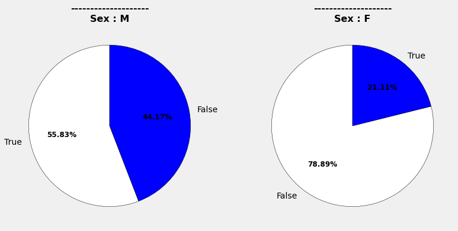

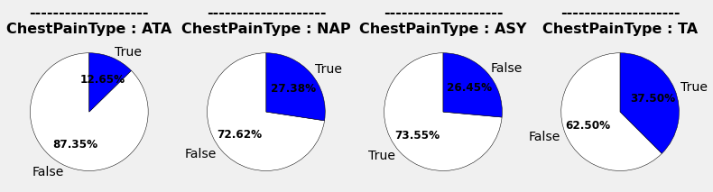

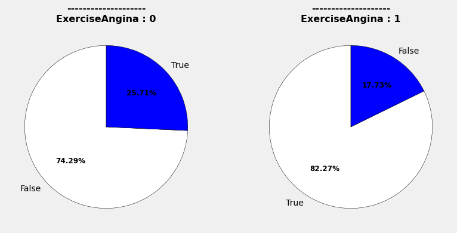

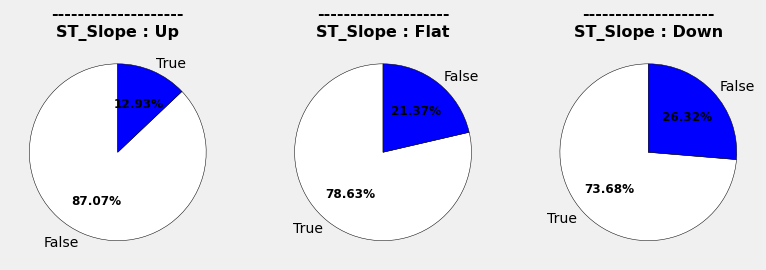

# Conclusions:

**limitation We could have built a stronger model if we got more enough data**

1-S_T slope highly correlated with heart disease

2-data has been gathered from males more than females however heart disease more likely to occure in men than females

4-if ST_slope tends to be Flat or down individual more likely to get a heart disease

[output not shown]